# SPARTIN-General-Usage

# Introduction

This vignette will explain how to use the most important parts of the SPARTIN pipeline. We begin by loading the package, and setting a seed for reproducibility:

```r
library(spatstat)
library(SPARTIN)
library(purrr)
set.seed(10000)
```

The following two functions are purely for visualization. They aren’t technically part of the package (yet), but you may find them useful if you decide to use this package. Regardless, we’ll be using them for this vignette.

```r
CustomHeatmap = CH = function(m, t="", min.v = NA, max.v = NA){
  plot.tib = tibble(r = numeric(0), c = numeric(0), val = numeric(0))
  for(i in 1:nrow(m)){
    plot.tib = bind_rows(plot.tib, tibble(
      r = rep(i, ncol(m)),
      c = 1:ncol(m),
      val = as.numeric(m[i,])))
  }

  plot.tib$c = as.factor(plot.tib$c)

  if(is.na(min.v) || is.na(max.v)){
    min.v = min(plot.tib$val, na.rm = T)
    max.v = max(plot.tib$val, na.rm = T)
  }
  cols = colorRampPalette(c("#0a0722", "#3d0965", "#721a6e", "#a52c60", "#d44842",
                            "#f37819", "#fcb216"))(7) #, "#f1f179"))(8)

  ggplot(plot.tib) +
    geom_tile(mapping = aes(x = c, y = reorder(r, -r), fill = val)) +
    labs(fill = "") +
    ggtitle(t) +
    scale_fill_gradientn(colors = cols,
                         limits = c(min.v, max.v),
                         # breaks = seq(min.v, max.v, 2),
                         na.value = 'white') +
    theme(axis.title.y=element_blank(),
          axis.text.y=element_blank(),
          axis.ticks.y=element_blank(),
          axis.title.x=element_blank(),
          axis.text.x=element_blank(),
          axis.ticks.x=element_blank(),
          panel.background = element_rect(fill = "white",
                                          colour = "black"),
          panel.border = element_rect(linetype = "solid", fill = NA))
}

# Visualize PPP
vis = function(p, t="", suppWarn = F){
  if(suppWarn){
    suppressWarnings(
      plot(p, cols = c("black", "red"),
           shape = c("circles", "circles"),
           size = 6,
           main = t)
    )
  }else{
    plot(p, cols = c("black", "red"),
         shape = c("circles", "circles"),
         size = 6,
         main = t)
  }
}
```

# Simulation and Model Fitting

First, we’ll simulate some data.

```r
ex_ppp = SimulateData(n1 = 100, n2 = 40, phi = 0.3,
                      winX = 300, winY = 300, r = 30)
```

Breaking down this function call:

- `n1` specifies the number of points of type 1
- `n2` specifies the number of points of type 2
- `phi` specifies the interaction between the points, -1 being the most negative (points of different types tend to “avoid” each other) and 1 being the most positive (points of different types tend to be close together)
- `winX` specifies the horizontal width of the window of simulation
- `winY` specifies the vertical height of the window of simulation
- `r` specifies the radius of interaction

Next, we’ll fit a Frequentist version of the model using the `FitHSFreq` function. The “HS” stands for “Hierarchical Strauss,” the variant of the model that we’ll be using. This is essentially a wrapper around the `spatstat` function `ppm` with certain parameters, since the SPARTIN pipeline uses a special case of the Hierarchical Strauss model. Below, I pass the point process we simulated, and specify that the radius of interaction is 30 units, and that the quadrature used in the fitting should have 3 units of space between each point. As always, there is a tradeoff here: the larger the quadrature (and thus the smaller that `quad.spacing` parameter), the more accurate the fitting will be. However, it will also be more computationally expensive. On the other hand, a small quadrature may lead to quicker fittings, but may also be less accurate. Unfortunately, there isn’t a one size fits all solution to this across all use cases. Some situations call for larger quadratures and more precise estimation, while for others a rough approximation will probably be fine.

```r
ex_freq = FitHSFreq(ex_ppp, r = 30, quad.spacing = 3)
coef(summary(ex_freq))
```

```
#>                 Estimate      S.E.    CI95.lo    CI95.hi Ztest         Zval
#> (Intercept) -6.802394763 0.1000000 -6.9983912 -6.6063984   *** -68.02394763
#> marks2      -0.936072712 0.4214038 -1.7620089 -0.1101365     *  -2.22132023
#> markX1xX2    0.006326801 0.1204110 -0.2296744  0.2423280         0.05254337
```

As expected, the interaction parameter (`markX1xX2`) is fairly close to zero, which makes sense given that we simulated weakly positive interaction.

We can also fit the same model using Bayesian methods. Here’s how we would fit a Bayesian version of the same model given above:

```r
ex_bayes = FitHSBayes(ex_ppp, r = 30, quad.spacing = 3)
```

```
#> module glm loaded
```

```r
ex_bayes
```

```
#> Inference for Bugs model at "/var/folders/jz/pkw0zld53pz3dxvzc5fs4hy00000gn/T//RtmpTeGciM/modelc63f7c57db97.txt", fit using jags,
#>  1 chains, each with 11000 iterations (first 1000 discarded), n.thin = 5
#>  n.sims = 2000 iterations saved
#>               mu.vect sd.vect       2.5%        25%        50%        75%
#> log.beta.1     -6.809   0.099     -7.008     -6.874     -6.803     -6.742
#> log.beta.2     -7.762   0.331     -8.413     -7.986     -7.747     -7.540
#> log.gamma       0.006   0.092     -0.178     -0.053      0.006      0.069
#> deviance   282260.902   2.368 282258.182 282259.172 282260.279 282261.990
#>                 97.5%
#> log.beta.1     -6.616
#> log.beta.2     -7.124
#> log.gamma       0.180
#> deviance   282266.853
#>
#> DIC info (using the rule, pD = var(deviance)/2)
#> pD = 2.8 and DIC = 282263.7
#> DIC is an estimate of expected predictive error (lower deviance is better).
```

There are a couple of important things to note. Firstly, you might notice that the object returned by the Frequentist fitting function is *very* different from the object returned by the Bayesian fitting function. That’s because the Frequentist version returns a `ppm` object defined in the `spatstat` package, whereas the Bayesian version returns an `rjags` object as defined by the `R2jags` package.

Secondly, you might notice that while two of the parameter estimates (`log.gamma`/`markX1xX2` and `log.beta.1`/`(Intercept)`) are virtually identical, the estimate for `marks2` is extremely different from `log.beta.2`. This is because `marks2` is actually the *difference* between the log first order intensity of points of type 1 ($\log(\beta_1)$) and the log first order intensity of points of type 2 ($\log(\beta_2)$), whereas `log.beta.2` is just the value of $\log(\beta_2)$. Sure enough, if you add the estimate of `(Intercept)` to the estimate of `marks2`, you should get something virtually identical to the estimate of `log.beta.2`.

# Estimating CTIP

In the paper associated with this package, we define CTIP. For a rigorous definition, I recommend checking the paper. For now, here is how you can use this package to calculate CTIP for a given point process realization:

```r
ex_CTIP = CTIP(ex_ppp, r = 30, quad.spacing = 3,
               n.null = 5, n.burn = 1000,
               n.sample = 11000, null.n.burn = 1000, null.n.sample = 11000,
               n.thin = 5)
ex_CTIP
```

```
#> [1] 0.503
```

Again, it’s worth breaking down this function call. I won’t go into too much detail here, but for more information on how CTIP is actually computed, see the SPARTIN paper.

- `ex_ppp` - This is the point process realization we want to estimate CTIP for.
- `n.null` - In order to compute CTIP, null simulations are performed; this parameter specifies how many should be performed. More simulations yield a more stable and accurate estimate, but naturally take longer.
- `n.burn` - Number of burn-in samples for the model fitting on the true data.
- `n.sample` - Total number of samples to draw when fitting the model on the true data.
- `null.n.burn` - Number of burn-in samples for the model fitting on the simulated data.
- `null.n.sample` - Total number of samples to draw for each null simulation in model fitting.
- `n.thin` - How much to “thin” each of the chains, both in the actual model fitting and the null model fitting

The total number of samples drawn on the true data is given by $\frac{n.sample - n.burn}{n.thin}$, while for the null simulations it’s $n.null \cdot \frac{null.n.sample - null.n.burn}{n.thin}$.

# Creating and Assessing Simulations

In the SPARTIN paper, we run a series of simulations to assess the ability of this metric to distinguish positive from non-positive interaction. The simulation function is included in this package. In fact, we have already used it- it is the `SimulateData` function discussed earlier. To reproduce the simulation results from the paper, simply choose the correct settings as detailed in section 3.1.1 of the paper. Here, we’ll simulate 50 tumor cells and 50 immune cells on a $300 \times 300$ window, mimicking simulation setting 3 of the paper:

```r
pos_sim = SimulateData(n1 = 50,
                       n2 = 50,
                       phi = 0.8,
                       winX = 300,
                       winY = 300,
                       r = 30)
```

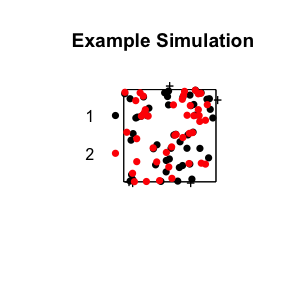

```r
plot(pos_sim, cols = c("black", "red"), pch = c(16, 16),
     main = "Example Simulation")
```

To compute CTIP for a given simulation, we can use the CTIP function as described in the previous section:

```r
CTIP(pos_sim, r = 30, quad.spacing = 3,
               n.null = 5, n.burn = 1000,
               n.sample = 11000, null.n.burn = 1000, null.n.sample = 11000,
               n.thin = 5)
```

```
#> [1] 0.9775
```

# Tesselation and Intensity Thresholding

Another important part of the SPARTIN pipeline is the intensity thresholding to remove excess whitespace. First, I’ll create a biopsy with a large amount of excess space.

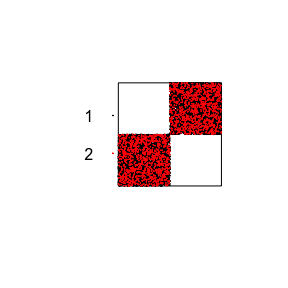

```r
# Simulate a biopsy
ex_biopsy_part_1 = SimulateData(n1 = 5000, n2 = 1000, phi = 0.4,
                         winX = 1000, winY = 1000, r = 30)

ex_biopsy_part_2 = SimulateData(n1 = 5000, n2 = 1000, phi = 0.4,
                         winX = 1000, winY = 1000, r = 30)

# Place in a large window to demonstrate intensity thresholding in action
ex_biopsy_excess = ppp(x = c(ex_biopsy_part_1$x, ex_biopsy_part_2$x - 1000),
                       y = c(ex_biopsy_part_1$y, ex_biopsy_part_2$y - 1000),
                       marks = c(ex_biopsy_part_1$marks,
                                 ex_biopsy_part_2$marks),
                       window = owin(xrange = c(-1000, 1000),
                                     yrange = c(-1000, 1000)))

vis(ex_biopsy_excess)
```

To see what each of the parameters do for this function, it’s probably best to directly read the documentation. Here, I’ll offer some advice on how to achieve a good tessellation/partition of the subspace. First, I’ll start with a bad example: sigma (the bandwidth) is too small and the threshold is too high. Thus, the resulting intensity thresholded window has too much unnecessary white space, and the resulting windows are too”choppy.” It also takes longer, and can lead to errors.

```r
bad_tessellation_1 = TessellateBiopsy(PPPToTibble(ex_biopsy_excess),
                                  sigma = 1, eps = 15,
                                  threshold = (ex_biopsy_excess$n)/
                                    area.owin(ex_biopsy_excess$window),
                                  clust.size = 75,
                                  max.clust.size = 100)
```

```
#> [1] "Intensity thresholding..."
#> [1] "Constructing window..."
#> [1] "Applying dirichlet tessellation..."
#> [1] "Creating clusters..."
#> [1] "Done"
```

Notice the “checkerboard” pattern of the tessellations:

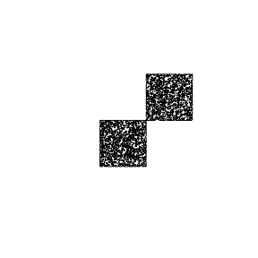

```r
vis(bad_tessellation_1$window)
```

This leads to poorly shaped tiles:

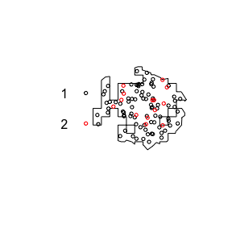

```r
vis(bad_tessellation_1$tiles[[1]])
```

Let’s try increasing the value of sigma. Note that all other parameters remain the same.

```r
good_tessellation = TessellateBiopsy(PPPToTibble(ex_biopsy_excess),
                                 sigma = 30, eps = 15,
                                 threshold = (ex_biopsy_excess$n)/
                                   area.owin(ex_biopsy_excess$window),
                                 clust.size = 75,
                                 max.clust.size = 100)
```

```
#> [1] "Intensity thresholding..."
#> [1] "Constructing window..."
#> [1] "Applying dirichlet tessellation..."
#> [1] "Creating clusters..."
#> [1] "Done"
```

This looks much better:

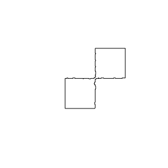

```r
vis(good_tessellation$window)
```

Ultimately, these are tuning parameters, and to find good values you may have to experiment a bit. The best advice I can offer is: start with a relatively large value of `sigma` (at least as large as `eps`), a relatively large value of `eps`, and a small `threshold`. Starting with a moderate `eps` is particularly important- if it’s too small, the tessellation will not be computationally tractable. Once you have a working tessellation, reduce the values of sigma and eps as necessary, and increase the threshold as necessary. In my experience, the settings that work for one data set of a certain type will work for others; you should only need to go through this process once.

# Interactive Visualization

Suppose you want to visualize all of the tiles all together, and a value associated with each tile. To do this, you can simply use the `PlotTessellation` function. First, we need a value to plot for each tile. In this case, I’ll use the number of simulated tumor cells:

```r
# Result is a vector, each entry of which is the number of tumor cells
# in the corresponding tile of the tessellation
bad_tes_n_tum = map_dbl(bad_tessellation_1$tiles, ~ sum(.x$marks == 1))
good_tes_n_tum = map_dbl(good_tessellation$tiles, ~ sum(.x$marks == 1))
```

Then we pass both these things to the `PlotTessellation` function:

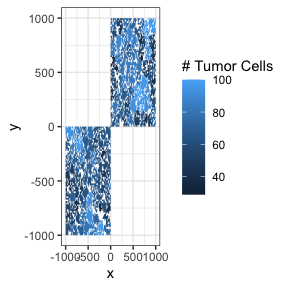

```r
PlotTessellation(bad_tessellation_1, bad_tes_n_tum, "# Tumor Cells")
```

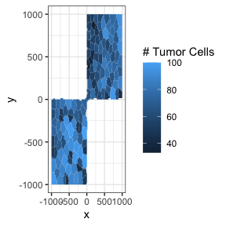

```r
PlotTessellation(good_tessellation, good_tes_n_tum, "# Tumor Cells")
```

However, there are clear limitations to this visualization method. What if you want to zoom in on a particular tile? Unfortunately, there’s no easy way to do this in R. However, this can be easily accomplished in the companion web app, and the `ExportToVis` function. This function exports a tessellation as well as associated values so that they can be interactively visualized here: https://nateosher.github.io/SPARTIN.html.

In fact, unlike the static visualization above, it’s fairly easy to switch between multiple tile level summaries. First, we create a list of all of the tile level values we want to summarize. Each list entry should have the same set of keys, each of which will be a value we’re interested in. I’ll keep it simple here and just use three: number of cells, number of tumor cells, and number of immune cells:

```r
val_list = map(good_tessellation$tiles, function(t){
  list(
    Cells = t$n,
    Tumor = sum(t$marks == 1),
    Immune = sum(t$marks == 2)
  )
})
```

Then we export it. This command actually writes a `.json` file

```r
ExportToVis(good_tessellation, val_list, "path/where/you/want/output")
```

If you upload the resulting `.json` file to the visualization application, it will let you more easily examine multiple measures on the same biopsy, and zoom in on specific tiles to see the configuration of points.